library(e1071) # for skewness function

#Test for linear regression #ref-> https://www.machinelearningplus.com/machine-learning/complete-introduction-linear-regression-r/

“Linear regression is used to predict the value of a continuous variable Y based on one or more input predictor variables X. The aim is to establish a mathematical formula between the the response variable (Y) and the predictor variables (Xs).” #Using the cars dataset to find a corealtion between dist and speed

```r
head(cars)
```

```
##   speed dist
## 1     4    2
## 2     4   10
## 3     7    4
## 4     7   22
## 5     8   16
## 6     9   10
```

“Scatter plot: Visualise the linear relationship between the predictor and response”

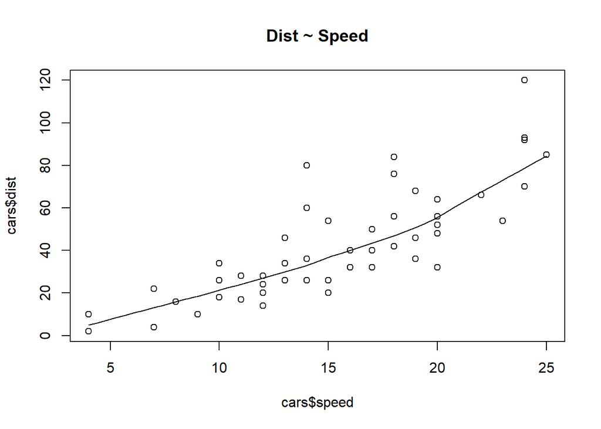

```r
scatter.smooth(x=cars$speed, y=cars$dist, main="Dist ~ Speed")  # scatterplot
```

```r
#a linear and positive relationship between the 'dist' and 'speed'.
```

“Box plot: To spot any outlier observations in the variable. Having outliers in your predictor can drastically affect the predictions as they can affect the direction/slope of the line of best fit.”

“Generally, an outlier is any datapoint that lies outside the 1.5 * inter quartile range (IQR). IQR is calculated as the distance between the 25th percentile and 75th percentile values for that variable.” # divide graph area in 2 columns

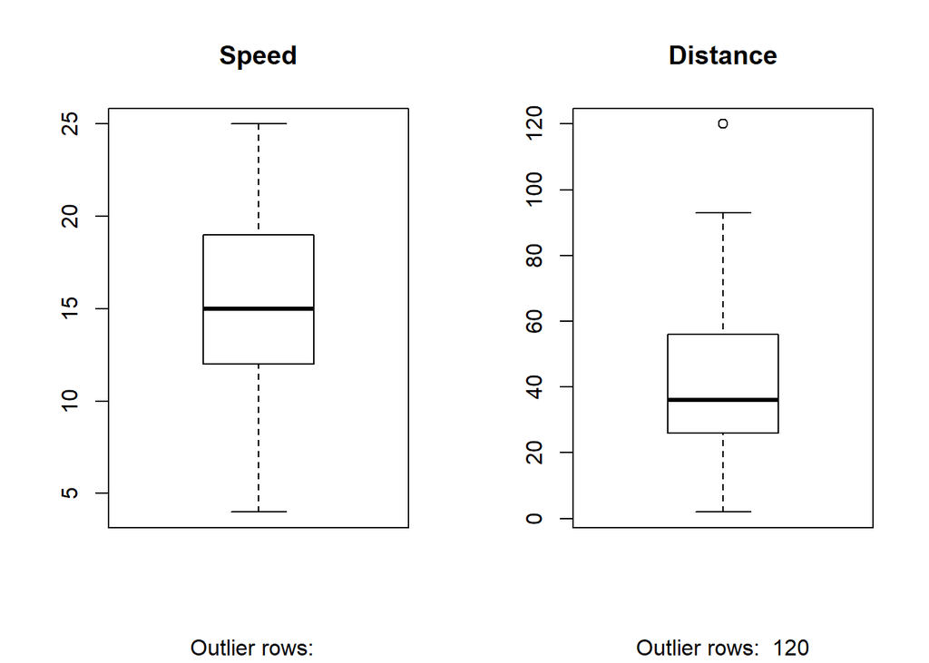

```r
par(mfrow=c(1, 2))
boxplot(cars$speed, main="Speed", sub=paste("Outlier rows: ", boxplot.stats(cars$speed)$out))  # box plot for 'speed'
boxplot(cars$dist, main="Distance", sub=paste("Outlier rows: ", boxplot.stats(cars$dist)$out))  # box plot for 'distance'
```

“Density plot: To see the distribution of the predictor variable. Ideally, a close to normal distribution (a bell shaped curve), without being skewed to the left or right is preferred.”

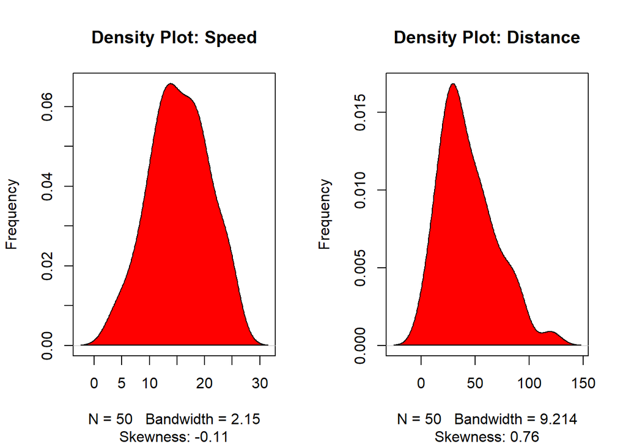

```r
par(mfrow=c(1, 2))  # divide graph area in 2 columns

plot(density(cars$speed), main="Density Plot: Speed", ylab="Frequency", sub=paste("Skewness:", round(e1071::skewness(cars$speed), 2)))  # density plot for 'speed'

polygon(density(cars$speed), col="red")

plot(density(cars$dist), main="Density Plot: Distance", ylab="Frequency", sub=paste("Skewness:", round(e1071::skewness(cars$dist), 2)))  # density plot for 'dist'

polygon(density(cars$dist), col="red")
```

```r
# calculate correlation between speed and distance
cor(cars$speed, cars$dist)
```

```
## [1] 0.8068949
```

```r
"This is an ideal co-relation anything between -1 to +1"
```

```
## [1] "This is an ideal co-relation anything between -1 to +1"
```

```r
"Building the linear regression model"
```

```
## [1] "Building the linear regression model"
```

```r
# build linear regression model on full data
linearMod <- lm(dist ~ speed, data=cars)
print(linearMod)
```

```
##
## Call:
## lm(formula = dist ~ speed, data = cars)
##
## Coefficients:
## (Intercept)        speed
##     -17.579        3.932
```

“Validating the statistical significance of our model” #The more the stars beside the variable’s p-Value, the more significant the variable.

```r
summary(linearMod)
```

```
##
## Call:
## lm(formula = dist ~ speed, data = cars)
##
## Residuals:
##     Min      1Q  Median      3Q     Max
## -29.069  -9.525  -2.272   9.215  43.201
##
## Coefficients:
##             Estimate Std. Error t value Pr(>|t|)
## (Intercept) -17.5791     6.7584  -2.601   0.0123 *
## speed         3.9324     0.4155   9.464 1.49e-12 ***
## ---
## Signif. codes:  0 '***' 0.001 '**' 0.01 '*' 0.05 '.' 0.1 ' ' 1
##
## Residual standard error: 15.38 on 48 degrees of freedom
## Multiple R-squared:  0.6511, Adjusted R-squared:  0.6438
## F-statistic: 89.57 on 1 and 48 DF,  p-value: 1.49e-12
```

#Testing the model #Create train and test data set

```r
set.seed(100)  # setting seed to reproduce results of random sampling
trainingRowIndex <- sample(1:nrow(cars), 0.8*nrow(cars))  # row indices for training data
trainingData <- cars[trainingRowIndex, ]  # model training data
testData  <- cars[-trainingRowIndex, ]   # test data
```

```r
# build the model
lmMod <- lm(dist ~ speed, data=trainingData)
# predict distance
distPred <- predict(lmMod, testData)
```

```r
# make actuals_predicteds dataframe.
actuals_preds <- data.frame(cbind(actuals=testData$dist, predicteds=distPred))
correlation_accuracy <- cor(actuals_preds)  # 82.7%
head(actuals_preds)
```

```
##    actuals predicteds
## 3        4   9.627845
## 5       16  13.886057
## 17      34  35.177120
## 24      20  43.693545
## 28      40  47.951757
## 32      42  56.468182
```

“you can compute all the error metrics in one go using the regr.eval() function in DMwR package.”

```r
DMwR::regr.eval(actuals_preds$actuals, actuals_preds$predicteds)
```

```
##         mae         mse        rmse        mape
##  12.5069370 267.0002421  16.3401420   0.4959096
```